# Assignment #6

Ethan Jantz

11/6/2020

This document is made using [R Markdown](https://rmarkdown.rstudio.com/), a great tool for sharing research in a way that is readable and reproducible.

## Assignment 6

Using chi squared tests, answer the following two questions:

```
1. Do men and women differ in their highest level of education (V161270)?
    Recategorize education into 4 categories: Less than a High School Degree, High school or High school Equivalent, Some College/Associates Degree, and 4 Year Degree and Higher.

2. Does the proportion of people who support the 2010 health care law (V161113) vary depending on their religion (V161265x)?
    For the sake of this statistical test, combine the three Protestant groups into one category and combine Jewish and "Other Religion" into one category.
    Your categories should then be Protestants, Catholics, Undifferentiated Christian, Other Religion, and Not Religious.
```

Explain in full sentences what you are doing and why you are doing it. Interpret the results. Do not only paste R output into the document but instead include it with your description of what the output means.

```r
knitr::opts_chunk$set(echo = TRUE, message = FALSE, warning = FALSE) # R Markdown options
library(tidyverse); library(gridExtra) # For putting plots side-by-side, trying out a different package this time
library(rmarkdown) # For accessing the functions used to display tables
library(haven) # For reading ANES2016.dta file
library(descr) # For CrossTable()
library(DescTools) # For CramerV()

anes <- haven::read_dta("ANES2016.dta") # Reading in the data
```

# Part A

## Select and Recode Variables

First, I’ll be selecting and recoding the variables. The select function selects and renames the variables, the filter function removes observations that have inapplicable responses, the mutate function recodes variables. In this case every variable selected is turned into a factor.

```r
selected <- anes %>%
  select(
    "Gender" = V161342,
    "Education" = V161270,
    "Health_Law_Support" = V161113,
    "Religion" = V161265x
  ) %>%
  filter(
    Gender %in% c(1,2),
    Education %in% c(1:90), # 5 respondents responded "other" and then specified "High School Graduate" and that is coded as 90
    Health_Law_Support %in% c(1:3),
    Religion %in% c(1:8)
  ) %>%
  mutate(
    Gender = factor(Gender, labels = c("Male", "Female")),
    Education = case_when(
      Education %in% c(1:8) ~ 1, # no high school
      Education %in% c(9,90) ~ 2, # high school or equivalent
      Education %in% c(10:12) ~ 3, # some college or associates degree
      Education %in% c(13:16) ~ 4, # college degree or higher
    ) %>%
      factor(labels = c("Less than a High School Degree", "High School Degree or GED",
                        "Some College/Associates Degree", "4 Year Degree and Higher")),
    Health_Law_Support = factor(Health_Law_Support, labels = c("Favor", "Oppose", "Neither favor nor oppose")),
    Religion = factor(Religion) %>%
      fct_collapse(
        Protestant = c("1", "2", "3"),
        Catholic = "4",
        "Undifferentiated Christian" = "5",
        Other = c("6", "7"),
        "Not Religious" = "8"
      )
  )
```

## Comparing Education Attainment by Gender

Here I’m running both the CrossTable (part of the *descr* library) and chisq.test (part of base R). I’m passing **chisq = TRUE** to CrossTable() to compare the results to the base R chisq.test function. The results of this test will tell me if there is an association between educational attainment and gender within the sample population.

```r
Education_Gender_CTable <- CrossTable(selected$Education, selected$Gender, prop.c = TRUE, prop.r = TRUE,
                               chisq = TRUE, total.r = TRUE, total.c = TRUE, expected = TRUE)
Education_Gender_chisq.test <- chisq.test(selected$Education, selected$Gender)

Education_Gender_CTable
```

```
##    Cell Contents
## |-------------------------|
## |                       N |
## |              Expected N |
## | Chi-square contribution |
## |           N / Row Total |
## |           N / Col Total |
## |         N / Table Total |
## |-------------------------|
##
## ========================================================
##                                   selected$Gender
## selected$Education                 Male   Female   Total
## --------------------------------------------------------
## Less than a High School Degree      142      129     271
##                                   127.8    143.2
##                                   1.589    1.417
##                                   0.524    0.476   0.065
##                                   0.073    0.059
##                                   0.034    0.031
## --------------------------------------------------------
## High School Degree or GED           383      413     796
##                                   375.2    420.8
##                                   0.160    0.143
##                                   0.481    0.519   0.192
##                                   0.196    0.188
##                                   0.092    0.100
## --------------------------------------------------------
## Some College/Associates Degree      651      822    1473
##                                   694.4    778.6
##                                   2.711    2.418
##                                   0.442    0.558   0.355
##                                   0.333    0.375
##                                   0.157    0.198
## --------------------------------------------------------
## 4 Year Degree and Higher            778      827    1605
##                                   756.6    848.4
##                                   0.604    0.539
##                                   0.485    0.515   0.387
##                                   0.398    0.377
##                                   0.188    0.200
## --------------------------------------------------------
## Total                              1954     2191    4145
##                                   0.471    0.529
## ========================================================
##
## Statistics for All Table Factors
##
## Pearson's Chi-squared test
## ------------------------------------------------------------
## Chi^2 = 9.581844      d.f. = 3      p = 0.0225
```

```r
Education_Gender_chisq.test
```

```
##
##  Pearson's Chi-squared test
##
## data:  selected$Education and selected$Gender
## X-squared = 9.5818, df = 3, p-value = 0.02248
```

We can see that the results of the tests between the functions are the same. The benefit to running CrossTable is its built-in description of the data. This is powerful, since I can see that there’s likely a weak association between gender and educational attainment and not a strong one, but I still need to run another test to say so confidently. I’m using Cramer’s V test because both variables are categorical/nominal and differ in the number of categories.

```r
CramerV(selected$Education, selected$Gender)
```

```
## [1] 0.04807976
```

> **Answer** The p-value for both chi-squared tests was the same (.0225) and significant (< .05), so we can say that there is an association. The result of Cramer’s V test shows that this association is weak (.048).

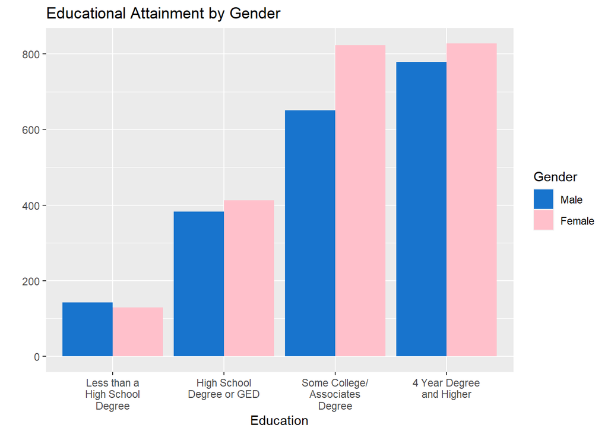

```r
selected %>%
  ggplot(aes(x = Education, fill = Gender)) +
  geom_bar(position = "dodge") +
  labs(y = "", title = "Educational Attainment by Gender") +
  scale_fill_manual(values = c("dodgerblue3", "pink")) +
  scale_x_discrete(labels = function(x) str_wrap(x, width = 15)) # Tidies up the x-axis labels so they don't overlap
```

# Part B

## Comparing Support for Health Care Law by Religious Affiliation

Here is the text detailing the meaning of the health care law question:

```
Do you favor, oppose, or neither favor nor oppose the health care reform law passed in 2010? This law requires all Americans to buy health insurance and requires health insurance companies to accept everyone.
```

I’ll be running the chi-squared test of independence between the respondent’s support for health care law and their religious affiliation.

```r
HealthLawSupport_Religion <- chisq.test(selected$Health_Law_Support, selected$Religion)

HealthLawSupport_Religion
```

```
##
##  Pearson's Chi-squared test
##
## data:  selected$Health_Law_Support and selected$Religion
## X-squared = 67.901, df = 8, p-value = 1.285e-11
```

Here we can see that there is an association. Let’s visualize the data and see what that shows before we move into testing with Cramer’s V, which I selected because I am looking at two categorical variables, one of which is ordinal and the other nominal.

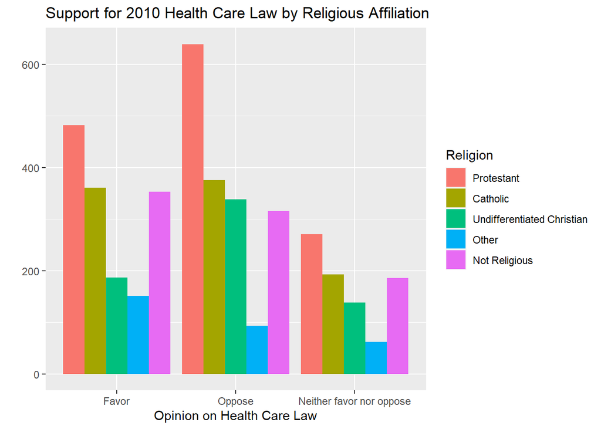

```r
selected %>%
  ggplot(aes(x = Health_Law_Support, fill = Religion)) +
  geom_bar(position = "dodge") +
  labs(x = "Opinion on Health Care Law", y = "", title = "Support for 2010 Health Care Law by Religious Affiliation")
```

This is a very busy graph, but it looks like there is some association in multiple categories. Protestant certainly sticks out. Let’s see what the strength of this association is.

```r
CramerV(selected$Health_Law_Support, selected$Religion)
```

```
## [1] 0.09050245
```

> **Answer** The result of the chi-squared test (p < .001) implies an association between respondents’ religion and their opinion on the 2010 health care law. Cramer’s V test (.09) reports that that association is weak.

It would be interesting to see how the Protestant response breaks down among its sub-categories.